# Progetto Data Analytics

#### *price ~ make*

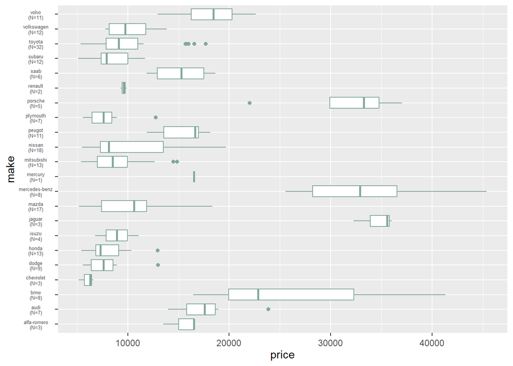

Prendendo le variabili *make* e *price* risulta lampante la dipendenza del prezzo dalla marca dell’auto, infatti:

```
##              Df    Sum Sq   Mean Sq F value Pr(>F)
## make         21 1.005e+10 478700877   33.23 <2e-16 ***
## Residuals   179 2.578e+09  14404773
## ---
## Signif. codes:  0 '***' 0.001 '**' 0.01 '*' 0.05 '.' 0.1 ' ' 1
## 4 osservazioni eliminate a causa di valori mancanti
```

Il test *ANOVA* da una forte correlazione tra le variabili. Se la variabile precedente è più difficile da spiegare, il fatto che le auto cambino di prezzo dipendentemente dal produttore ci sembra più intuitivo.

#### *price ~ fuelType*

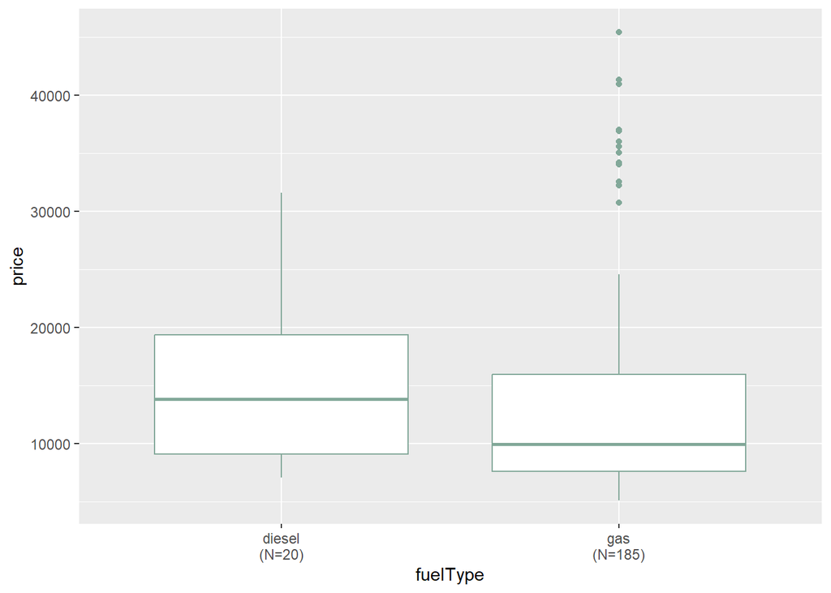

```
##              Df    Sum Sq   Mean Sq F value Pr(>F)
## fuelType      1 1.537e+08 153743226   2.452  0.119
## Residuals   199 1.248e+10  62700651
## 4 osservazioni eliminate a causa di valori mancanti
```

La relazione tra *fuelType* e *price* sembra invece far propendere per una sostanziale indipendenza delle variabili. Il test *ANOVA* sembra dare un valore parecchio elevato per rifiutare l’ipotesi di indipendenza.

#### *price ~ bodyStyle*

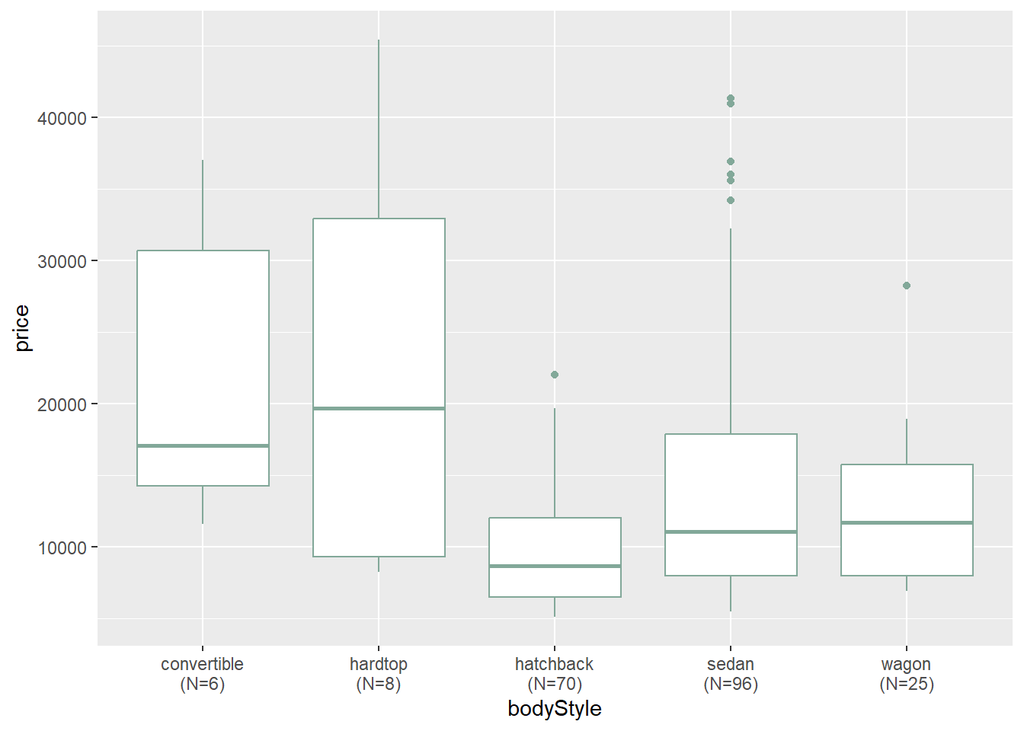

```
##              Df    Sum Sq   Mean Sq F value   Pr(>F)
## bodyStyle     4 1.984e+09 495911393   9.129 8.78e-07 ***
## Residuals   196 1.065e+10  54324118
## ---
## Signif. codes:  0 '***' 0.001 '**' 0.01 '*' 0.05 '.' 0.1 ' ' 1
## 4 osservazioni eliminate a causa di valori mancanti
```

Invece la variabile *bodyStyle* sembra presentare una dipendenza dal prezzo apprezzabile. Questo può essere dipeso dal fatto che una forma particolare del telaio può richiedere più costo nell’essere ideata, in più auto con motori più potenti tendono ad avere intelaiature simili.

#### *price ~ driveWheels*

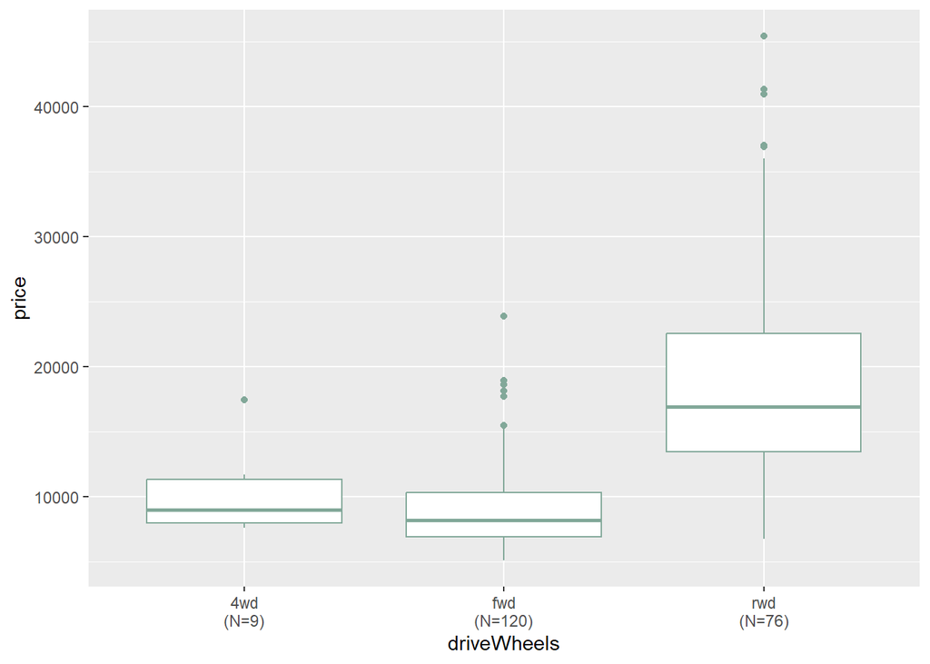

Dal tipo di trazione dell’auto sembra dipendere molto il prezzo, soprattutto per le auto con trazione posteriore, che aumentano di molto di prezzo.

```
##              Df    Sum Sq   Mean Sq F value Pr(>F)
## driveWheels   2 5.141e+09 2.571e+09   67.95 <2e-16 ***
## Residuals   198 7.490e+09 3.783e+07
## ---
## Signif. codes:  0 '***' 0.001 '**' 0.01 '*' 0.05 '.' 0.1 ' ' 1
## 4 osservazioni eliminate a causa di valori mancanti
```

Questa ipotesi sembra essere corroborata anche dal test *ANOVA*. Questo aumento di prezzo per le auto a trazione posteriore può essere spiegato con la difficoltà ingegneristica nella costruzione.

#### *price ~ engineType*

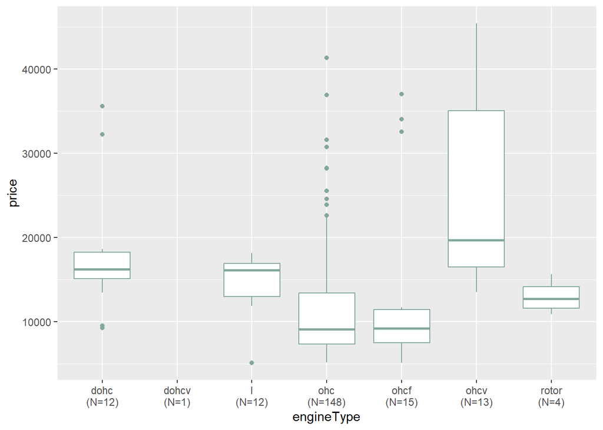

```
##              Df    Sum Sq   Mean Sq F value   Pr(>F)
## engineType    5 2.546e+09 509182165   9.845 2.09e-08 ***
## Residuals   195 1.009e+10  51719292
## ---
## Signif. codes:  0 '***' 0.001 '**' 0.01 '*' 0.05 '.' 0.1 ' ' 1
## 4 osservazioni eliminate a causa di valori mancanti
```

Il prezzo sembra dipendere anche dal tipo di motore.

#### *price ~ fuelSystem*

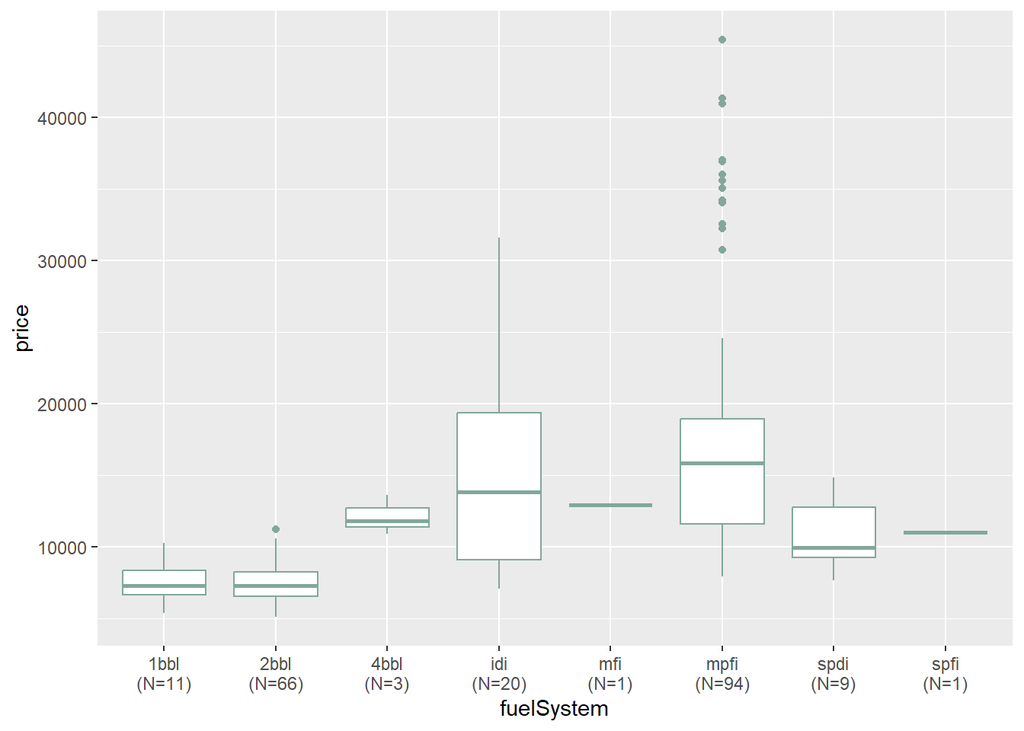

```
##              Df    Sum Sq   Mean Sq F value   Pr(>F)
## fuelSystem    7 4.455e+09 636467931   15.02 1.31e-15 ***
## Residuals   193 8.176e+09  42362162
## ---
## Signif. codes:  0 '***' 0.001 '**' 0.01 '*' 0.05 '.' 0.1 ' ' 1
## 4 osservazioni eliminate a causa di valori mancanti
```

Il tipo di iniezione sembra avere una forte dipendenza con il prezzo. Un problema con questa variabile però è la scarsa numerosità di certe categorie, fino a ridursi, in due categorie, a un singolo valore.

Dopo aver analizzato la matrice di correlazione bisogna andare ad indagare più approfonditamente, cercando di spiegare il legame che lega la variabile *price* con le altre.

Per questo uno strumento molto utile è il tracciare una curva con il metodo loess, che passi più vicino possibile ai punti del grafico, per far emergere un andamento da esso.

A questo si può aggiungere il calcolo della correlazione tra una variabile e la trasformata dell’altra per vedere se le variabili aumentano la loro correlazione.

#### *price ~ height*

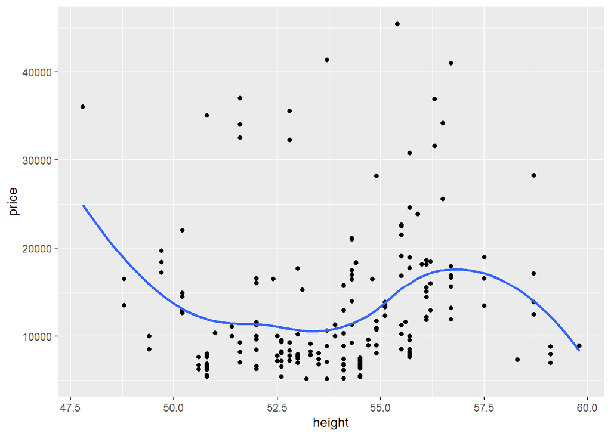

Nel grafico si vede un’andamento particolare che può ricordare una funzione cubica. A differenza però di quello che la curva suggerisce la correlazione tra l’altezza e il valore cubico del prezzo è molto basso, quindi la consideriamo poco esplicativa.

```r
cor(data$height,I((data$price)^3))
```

```
## [1] 0.0483375
```

#### *price ~ curbWeight*

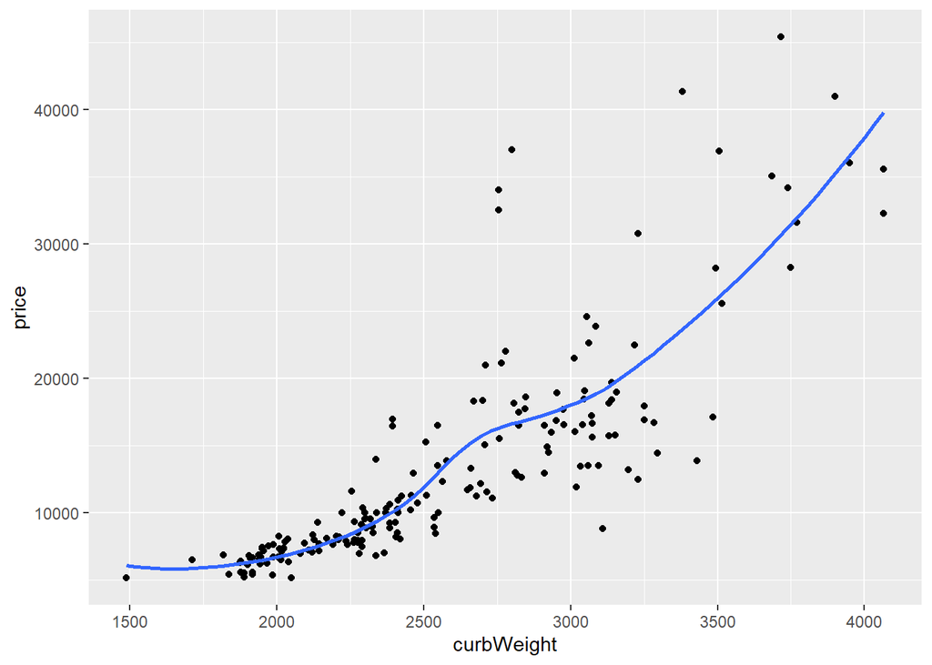

Questa volta si vede una curva che suggerisce un’andamento esponenziale e a differenza del precedente vi è una forte correlazione tra il logaritmo del prezzo e il peso della vettura.

```r
cor(I(log(data$price)), data$curbWeight)
```

```
## [1] 0.8945391
```

#### *price ~ engineSize*

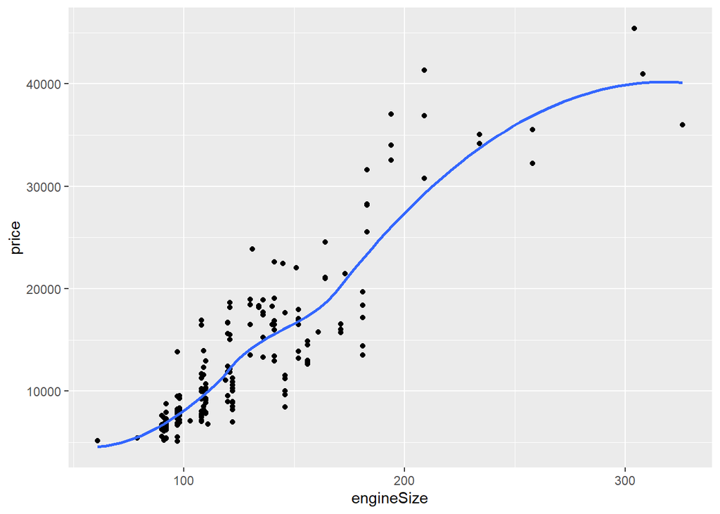

```r
cor(data$price, data$engineSize)
```

```
## [1] 0.8887785
```

La correlazione però va ad indicare che il rapporto più probabile è proprio quello lineare.

#### *price ~ horsepower*

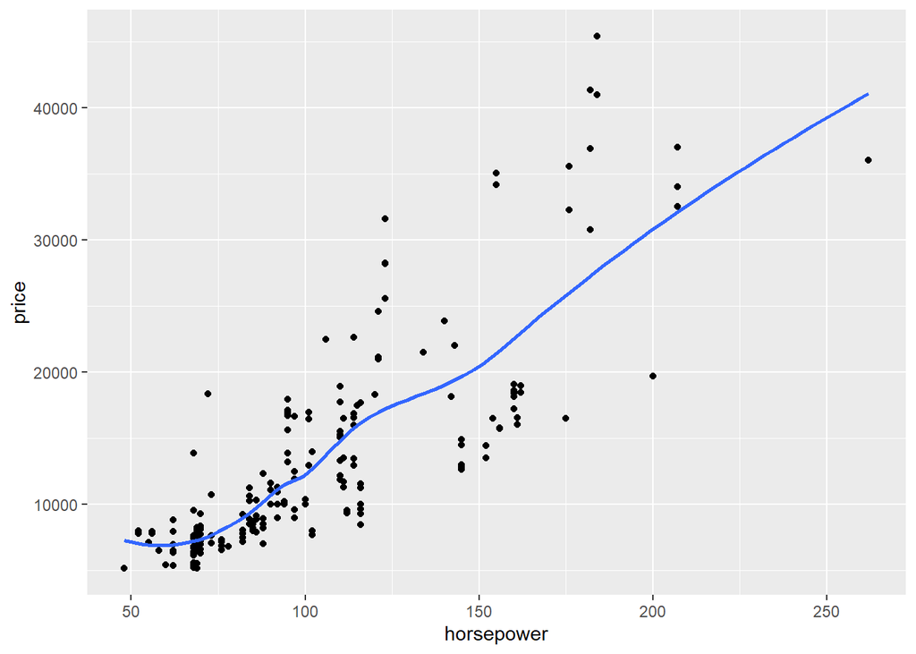

In questo grafico la curva sembra quasi trasformarsi in una retta, a suggerire un andamento lineare, che è anche quello suggerito dalla correlazione.

```r
cor(data$price, data$horsepower)
```

```
## [1] 0.8124532
```

#### *price ~ cityMpg*

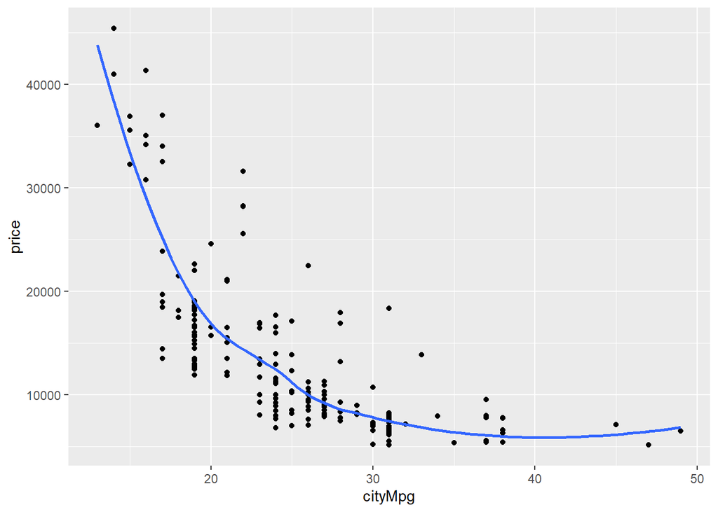

La curva disegnata nel grafico sembra molto simile a quella di una esponenziale inversa. Dal valore della correlazione non emergono sorprese, rafforzando la teoria di un’esponenziale inversa:

```r
cor(I(-log(data$price)), data$cityMpg)
```

```
## [1] 0.7918757
```

### Conclusioni

Queste analisi hanno fatto emergere dei rapporti tra variabili che però necessitano di studio aggiuntivo con modelli di regressione bivariata e successivamente multivariata. Pertanto questi valori sono un punto di partenza per i modelli che verranno studiati nel prossimo capitolo.

## 4. Modelli di regressione - lineare

Sono stati valutati i modelli di regressione lineare utilizzando come variabile dipendente il prezzo dell’auto. Nella seguente immagine sono indicati, in ordine decrescente, i valori di $R^2$ per ciascuna variabile. La significatività del modello è indicata dal colore dei punti.

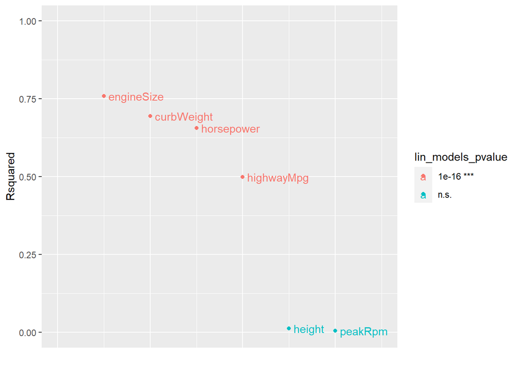

### Analisi dei modelli

Si osserva che le variabili *engineSize, curbweight, horsepower* e *highwayMpg* risultano significative con p-value minori di $10^{-16}$.

#### *price* *~ engineSize*

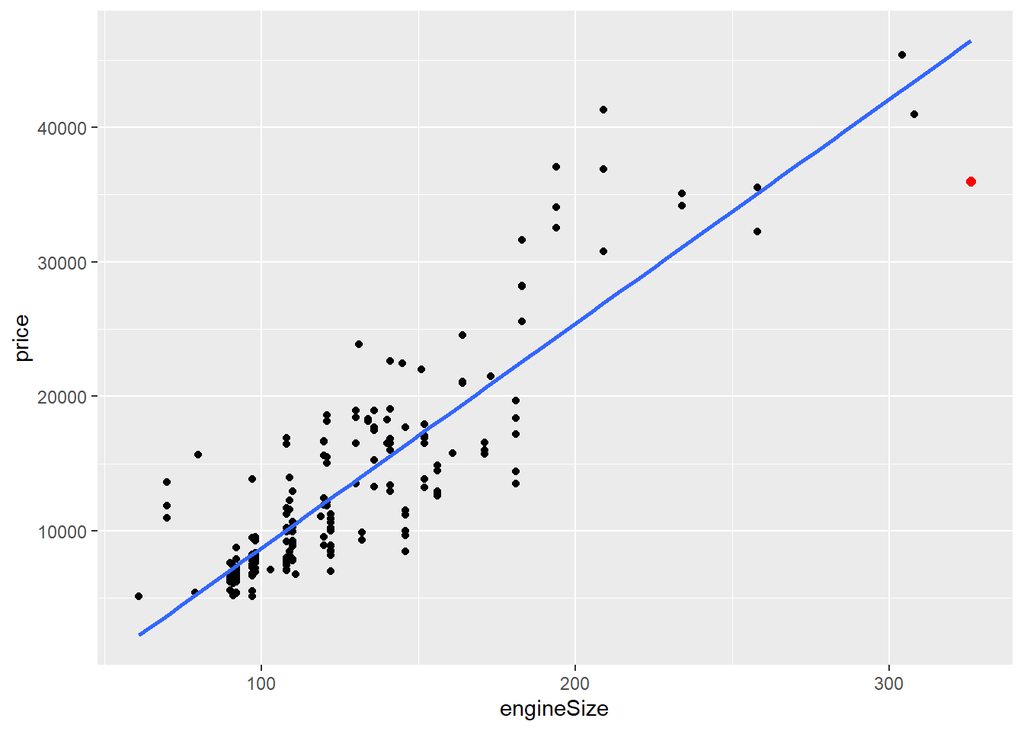

```
##    symboling   make fuelType aspiration numOfDoors bodyStyle driveWheels height
## 50         0 jaguar      gas        std        two     sedan         rwd   47.8
##    curbWeight engineType engineSize fuelSystem horsepower peakRpm highwayMpg
## 50       3950       ohcv        326       mpfi        262    5000         17
##    price
## 50 36000
```

```
##
## Call:
## lm(formula = price ~ engineSize, data = data)
##
## Residuals:
##      Min       1Q   Median       3Q      Max
## -10438.4  -2273.3   -477.3   1373.0  14398.2
##
## Coefficients:
##              Estimate Std. Error t value Pr(>|t|)
## (Intercept) -7954.991    891.444  -8.924 3.14e-16 ***
## engineSize    166.851      6.668  25.021  < 2e-16 ***
## ---
## Signif. codes:  0 '***' 0.001 '**' 0.01 '*' 0.05 '.' 0.1 ' ' 1
##
## Residual standard error: 3913 on 197 degrees of freedom
## Multiple R-squared:  0.7606, Adjusted R-squared:  0.7594
## F-statistic: 626.1 on 1 and 197 DF,  p-value: < 2.2e-16
```

- **Intercetta** = -7954.991
- **Pendenza** = 166.851

L’aumento di 1 unità di *engineSize* corrisponde all’aumento di 166.851 dollari per il prezzo. Il valore dell’intercetta -7954.991 non ha un interpretazione reale.

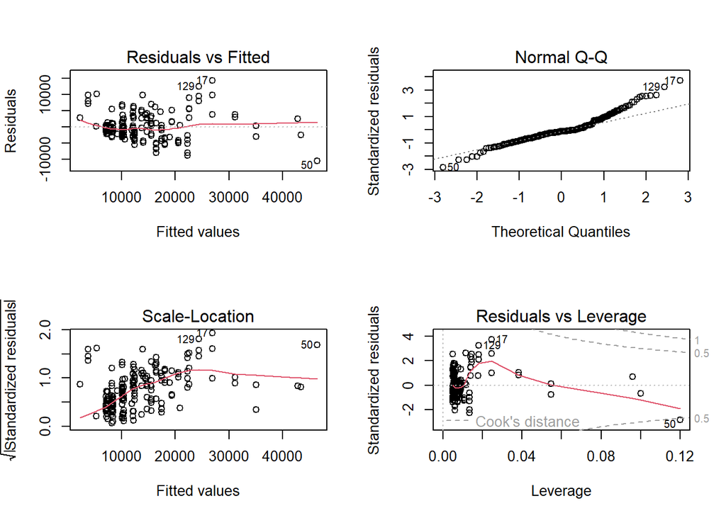

- **residual vs fitted**: si osserva un distribuzione dei residui lineare con un aumento di varianza per valori medi di *engineSize*
- **QQ-residual**: si osserva una violazione della normalità dei residui in prossimità delle code, in particolare per la coda destra
- **scale-location**: si osserva una violazione di omoschedasticità
- **residual Vs leverage**: si osserva la presenza di un valore outlier

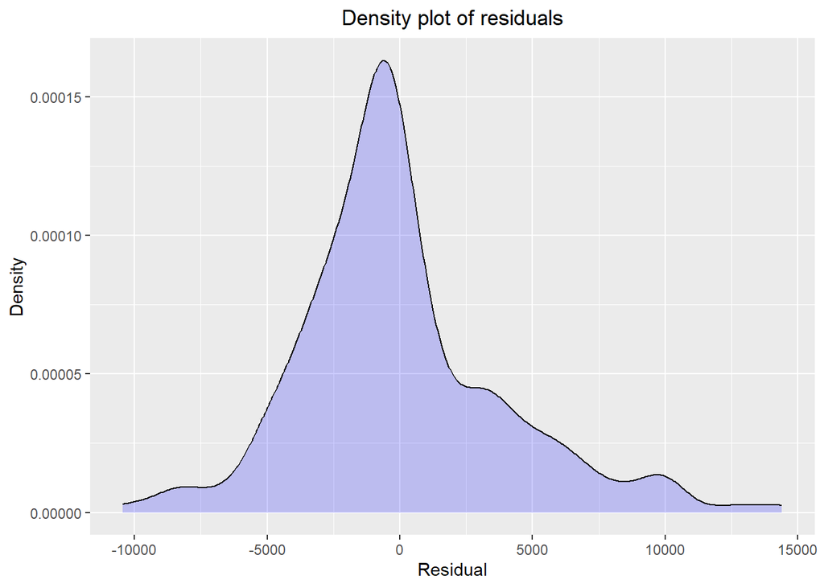

#### *price* *~ curbWeight*

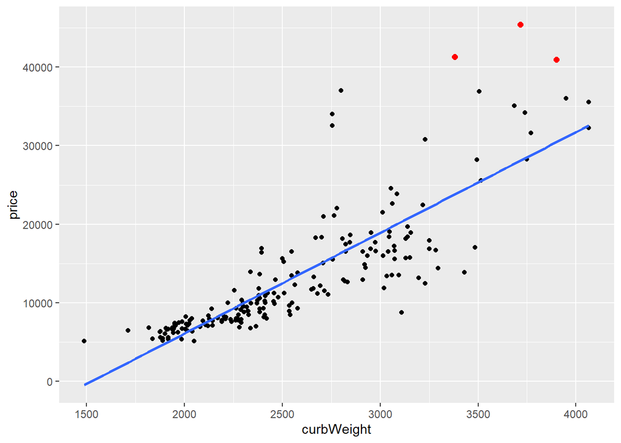

```
##     symboling          make fuelType aspiration numOfDoors   bodyStyle
## 127         3       porsche      gas        std        two     hardtop
## 128         3       porsche      gas        std        two     hardtop
## 129         3       porsche      gas        std        two convertible
## 17          0           bmw      gas        std        two       sedan
## 74          0 mercedes-benz      gas        std       four       sedan
## 75          1 mercedes-benz      gas        std        two     hardtop
##     driveWheels height curbWeight engineType engineSize fuelSystem horsepower
## 127         rwd   51.6       2756       ohcf        194       mpfi        207
## 128         rwd   51.6       2756       ohcf        194       mpfi        207
## 129         rwd   51.6       2800       ohcf        194       mpfi        207
## 17          rwd   53.7       3380        ohc        209       mpfi        182
## 74          rwd   56.7       3900       ohcv        308       mpfi        184
## 75          rwd   55.4       3715       ohcv        304       mpfi        184
##     peakRpm highwayMpg price
## 127    5900         25 32528
## 128    5900         25 34028
## 129    5900         25 37028
## 17     5400         22 41315
## 74     4500         16 40960
## 75     4500         16 45400
```

```
##
## Call:
## lm(formula = price ~ curbWeight, data = data)
##
## Residuals:
##      Min       1Q   Median       3Q      Max
## -11538.7  -2065.0   -319.7   1386.0  20684.5
##
## Coefficients:
##               Estimate Std. Error t value Pr(>|t|)
## (Intercept) -19543.945   1576.417  -12.40   <2e-16 ***
## curbWeight      12.817      0.604   21.22   <2e-16 ***
## ---
## Signif. codes:  0 '***' 0.001 '**' 0.01 '*' 0.05 '.' 0.1 ' ' 1
##
## Residual standard error: 4413 on 197 degrees of freedom
## Multiple R-squared:  0.6957, Adjusted R-squared:  0.6941
## F-statistic: 450.3 on 1 and 197 DF,  p-value: < 2.2e-16
```

Il modello lineare stimato utilizzando come variabile indipendente *curbWeight* mostra un $R^2$ pari a $0.6941$. I parametri stimati per l’intecetta e la pendenza della retta di regressione risultano entrambi significativi con p-value minore di $10^{-16}$.

- **Intercetta** = -19543.945
- **Pendenza** = 12.817

L’aumento di 1lb del veicolo corrisponde all’aumento di 12.817 dollari per il prezzo. Il valore dell’intercetta non ha un interpretazione reale, non è possibile che un automobile di peso nullo costi -19543.945 dollari.

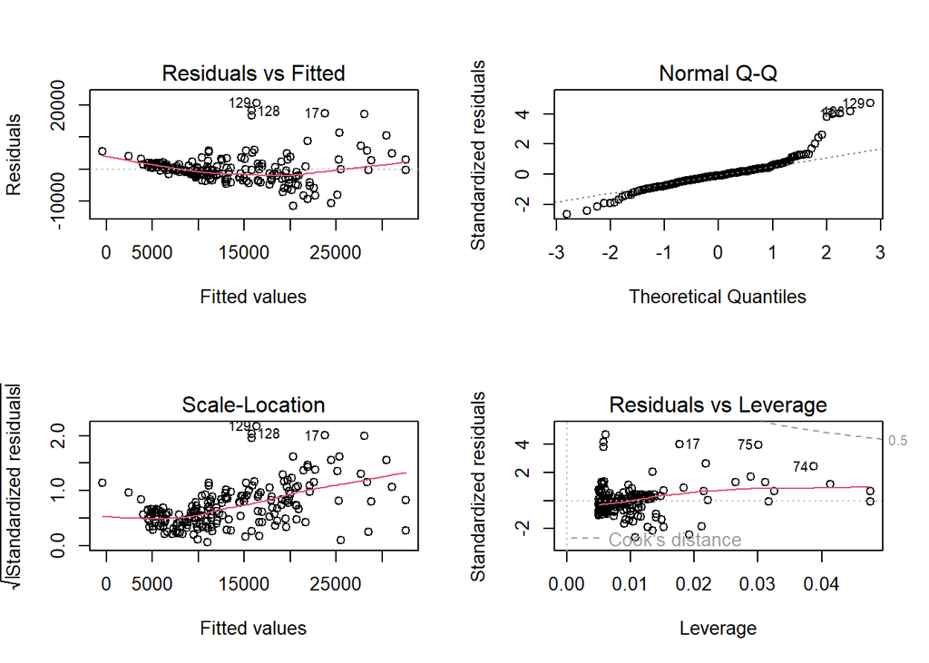

- **residual vs fitted**: si osserva una andamento lineare con una leggera curvatura. Si evidenzia un notevole aumento di varianza e relativa assenza di omoschedasticità
- **QQ-residual**: residui appaiono distribuiti normalmente solo per i valori intermedi, si evidenza una violazione di normalità molto marcata in prossimità delle code, in particolare la coda destra
- **scale-location**: si conferma il notevole aumento di varianza osservato nel grafico residual vs fitted
- **residual Vs leverage**: non si osservano dati outlier, ma si evidenza la possibile presenza di valori anomali

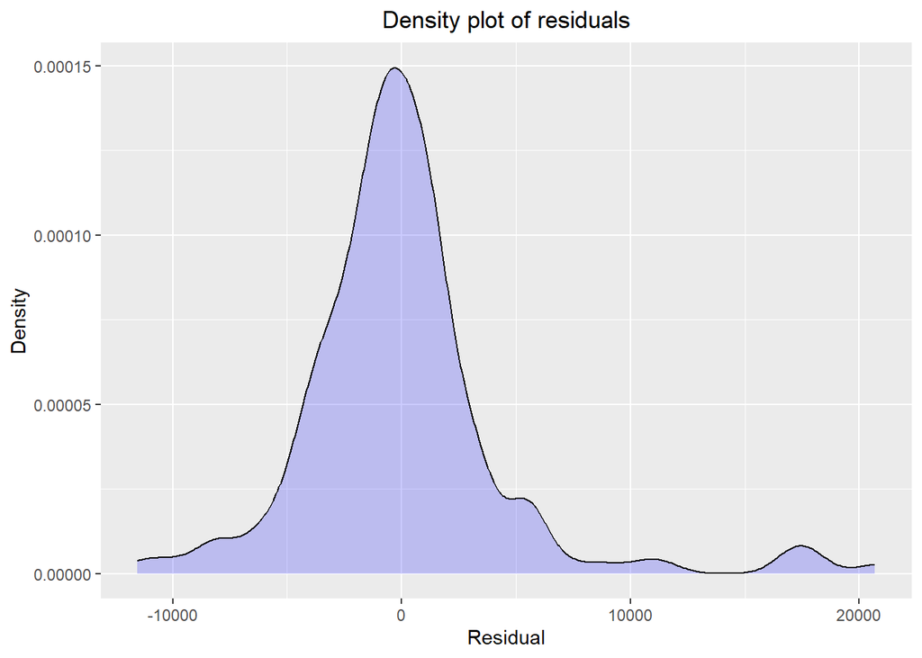

#### *price* *~ horsepower*

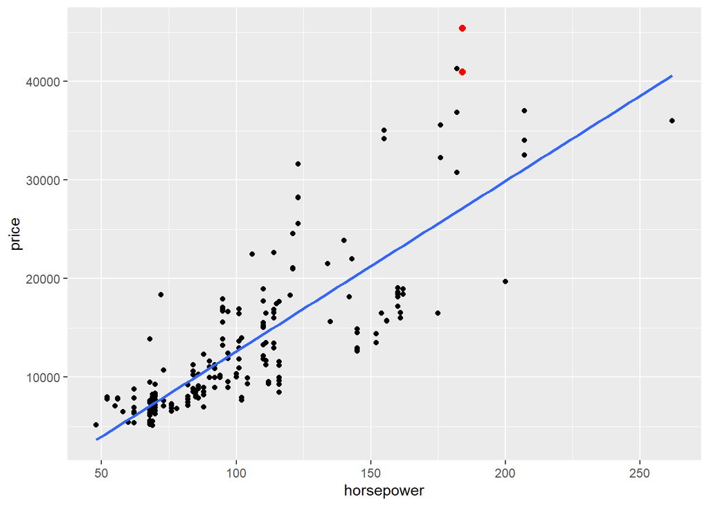

```
##    symboling          make fuelType aspiration numOfDoors bodyStyle driveWheels
## 18         0           bmw      gas        std       four     sedan         rwd
## 74         0 mercedes-benz      gas        std       four     sedan         rwd
## 75         1 mercedes-benz      gas        std        two   hardtop         rwd
##    height curbWeight engineType engineSize fuelSystem horsepower peakRpm
## 18   56.3       3505        ohc        209       mpfi        182    5400
## 74   56.7       3900       ohcv        308       mpfi        184    4500
## 75   55.4       3715       ohcv        304       mpfi        184    4500
##    highwayMpg price
## 18         20 36880
## 74         16 40960
## 75         16 45400
```

```
##
## Call:
## lm(formula = price ~ horsepower, data = data)
##
## Residuals:
##      Min       1Q   Median       3Q      Max
## -10197.9  -2281.1   -420.8   1815.0  18267.6
##
## Coefficients:
##             Estimate Std. Error t value Pr(>|t|)
## (Intercept) -4659.37     978.08  -4.764 3.68e-06 ***
## horsepower    172.78       8.88  19.456  < 2e-16 ***
## ---
## Signif. codes:  0 '***' 0.001 '**' 0.01 '*' 0.05 '.' 0.1 ' ' 1
##
## Residual standard error: 4680 on 197 degrees of freedom
## Multiple R-squared:  0.6577, Adjusted R-squared:  0.656
## F-statistic: 378.6 on 1 and 197 DF,  p-value: < 2.2e-16
```

- **Intercetta** = -4659.37
- **Pendenza** = 172.78

L’aumento di 1 cavallo del veicolo corrisponde all’aumento di 172.78 dollaro per il prezzo. Il valore dell’intercetta non ha un interpretazione reale, non è possibile che un automobile di 0 cavalli costi -4659.37 dollari.

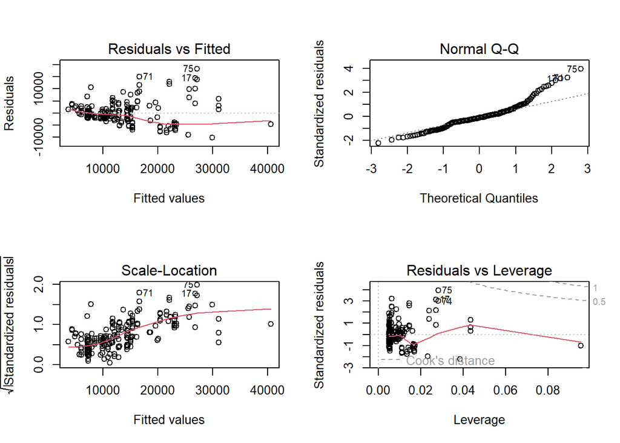

- **residual vs fitted**: si osserva una sostanziale linearità del modello con una leggera curvatura. Si evidenzia un aumento della varianza all’aumentare di *horsepower*
- **QQ-residual**: si osserva una violazione della normalità dei residui evidenziata da una coda pesante a destra
- **scale-location**: si conferma un aumento di varianza all’aumentare di *horsepower*
- **residual Vs leverage**: non si osservano dati outlier. Si osservano dei possibili valori anomali

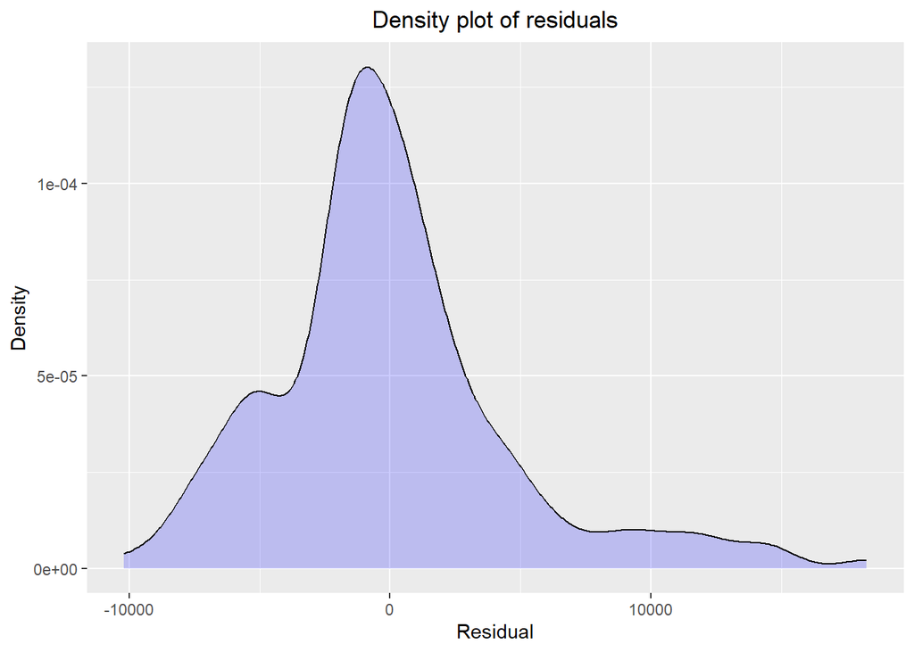

#### *price* *~ highwayMpg*

[figure not shown]

```
##    symboling          make fuelType aspiration numOfDoors bodyStyle driveWheels
## 19         2     chevrolet      gas        std        two hatchback         fwd
## 75         1 mercedes-benz      gas        std        two   hardtop         rwd
## 31         2         honda      gas        std        two hatchback         fwd
##    height curbWeight engineType engineSize fuelSystem horsepower peakRpm
## 19   53.2       1488          l         61       2bbl         48    5100
## 75   55.4       3715       ohcv        304       mpfi        184    4500
## 31   50.8       1713        ohc         92       1bbl         58    4800
##    highwayMpg price
## 19         53  5151
## 75         16 45400
## 31         54  6479
```

```
##
## Call:
## lm(formula = price ~ highwayMpg, data = data)
##
## Residuals:
##    Min     1Q Median     3Q    Max
##  -8689  -3361  -1036   1029  20901
##
## Coefficients:
##             Estimate Std. Error t value Pr(>|t|)
## (Intercept) 38687.64    1851.40   20.90   <2e-16 ***
## highwayMpg   -830.64      59.01  -14.08   <2e-16 ***
## ---
## Signif. codes:  0 '***' 0.001 '**' 0.01 '*' 0.05 '.' 0.1 ' ' 1
##
## Residual standard error: 5648 on 197 degrees of freedom
## Multiple R-squared:  0.5015, Adjusted R-squared:  0.4989
## F-statistic: 198.2 on 1 and 197 DF,  p-value: < 2.2e-16
```

Il modello lineare stimato utilizzando come variabile indipendente *highwayMpg* mostra un $R^2$ pari a $0.4989$. I parametri stimati per l’intecetta e la pendenza della retta di regressione risultano entrambi significativi con p-value minore di $10^{-16}$.

- **Intercetta** = 38687.64
- **Pendenza** = -830.64

L’aumento di 1 unità di *highwayMpg* corrisponde ad una diminuizione di 830.64 dollari per il prezzo. Non ha senso interpretare l’intercetta in quanto rappresenta il prezzo di una macchina che fa 0 miglia con 1 gallone, ovvero ha un consumo infinito.

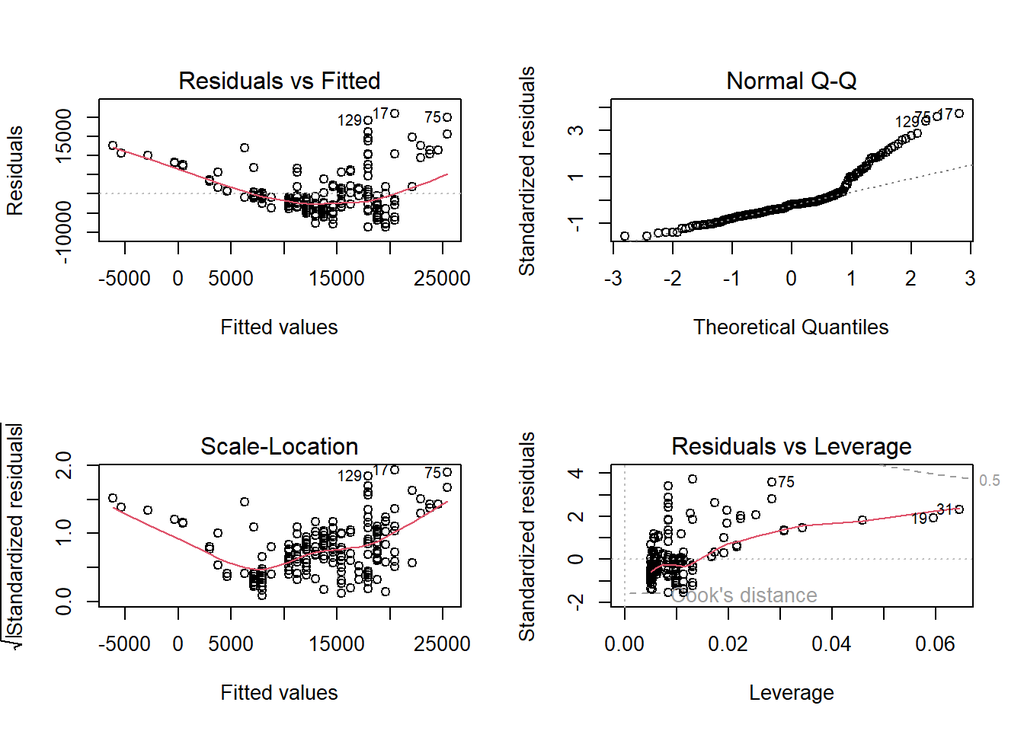

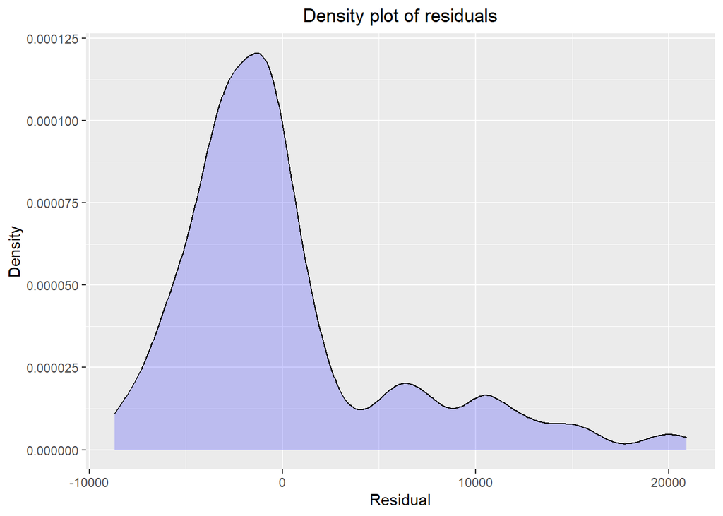

### Trasformazioni non lineari

L’analisi è stata ripetuta in maniera analoga (costruzione del modello lineare, valutazione del summary e dei residui), considerando una trasformazione logaritmica sulla variabile *price*, scelta vista la distribuzione fortemente asimmetrica con una lunga coda a destra della variabile e date le sue relazioni esponenziali con diverse variabili del dataset:

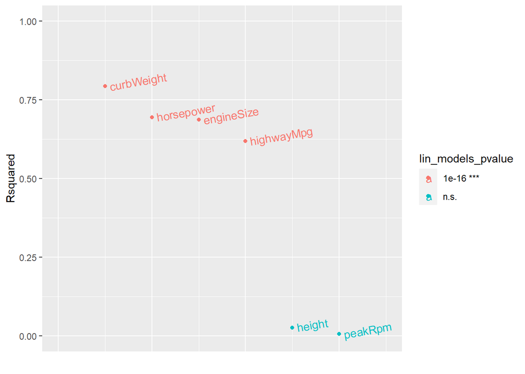

#### *log(price)* *~ curbWeight*

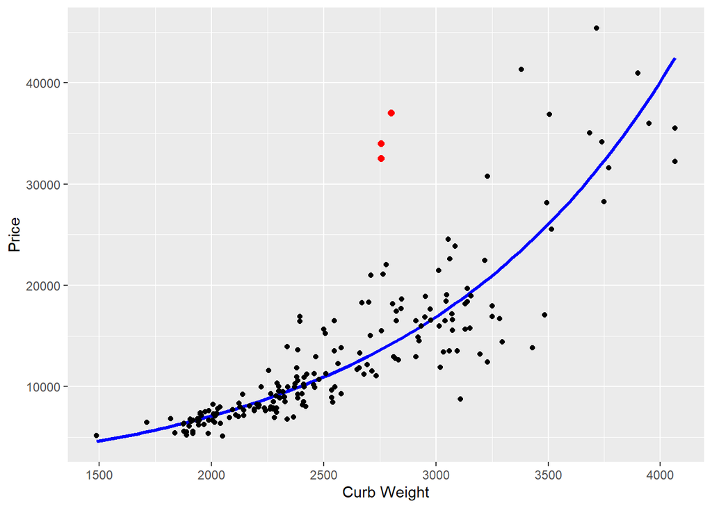

Nel seguente grafico sono evidenziati i valori 127,128,129 relativi ai modelli di porsche.

```
##     symboling    make fuelType aspiration numOfDoors   bodyStyle driveWheels
## 127         3 porsche      gas        std        two     hardtop         rwd
## 128         3 porsche      gas        std        two     hardtop         rwd
## 129         3 porsche      gas        std        two convertible         rwd
##     height curbWeight engineType engineSize fuelSystem horsepower peakRpm
## 127   51.6       2756       ohcf        194       mpfi        207    5900
## 128   51.6       2756       ohcf        194       mpfi        207    5900
## 129   51.6       2800       ohcf        194       mpfi        207    5900
##     highwayMpg price logPrice
## 127         25 32528 10.38986
## 128         25 34028 10.43494
## 129         25 37028 10.51943
```

```
##
## Call:
## lm(formula = logPrice ~ curbWeight, data = data)
##
## Residuals:
##      Min       1Q   Median       3Q      Max
## -0.74975 -0.13253 -0.02088  0.08312  0.95806
##
## Coefficients:
##              Estimate Std. Error t value Pr(>|t|)
## (Intercept) 7.137e+00  8.191e-02   87.13   <2e-16 ***
## curbWeight  8.657e-04  3.138e-05   27.59   <2e-16 ***
## ---
## Signif. codes:  0 '***' 0.001 '**' 0.01 '*' 0.05 '.' 0.1 ' ' 1
##
## Residual standard error: 0.2293 on 197 degrees of freedom
## Multiple R-squared:  0.7943, Adjusted R-squared:  0.7933
## F-statistic: 760.9 on 1 and 197 DF,  p-value: < 2.2e-16
```

Il modello lineare stimato utilizzando come variabile indipendente *curbWeight* mostra un $R^2$ pari a $0.7933$. I parametri stimati per l’intecetta e la pendenza della retta di regressione risultano entrambi significativi con p-value minore di $10^{-16}$. Si ricorda che il prezzo è stato trasformato con una trasformazione logaritmica e per un’interpretazione corretta è necessario ritrasmormare il prezzo.

- **Intercetta** = 7.137e+00
- **Pendenza** = 8.657e-04

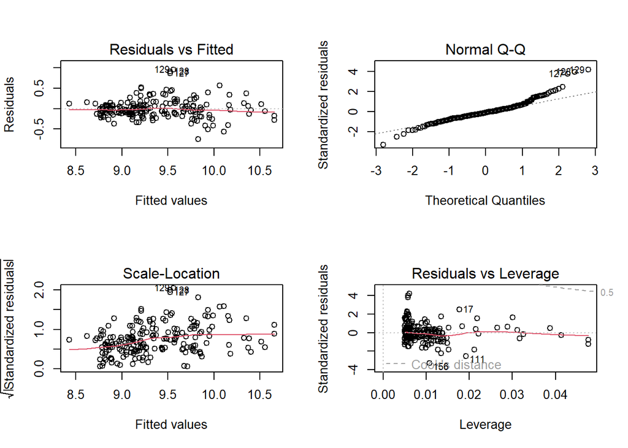

- **residual vs fitted**: la linea rossa parallela dimostra che la scelta di un modello lineare è appropriata. Si osserva una generale omoschedasticità con un leggero aumento della varianza all’aumentare del peso della macchina
- **QQ-residual:** si osserva una generale normalità dei residui con violazioni maggiori in corrispondenza delle code. I tre valori anomali sono dovuti a tre automobili di porsche
- **scale-location**: si osserva un aumento della varianza all’aumentare del peso della macchina. conferma quanto visto nel residual vs fitted
- **residual Vs leverage**: non si osservano dati outlier

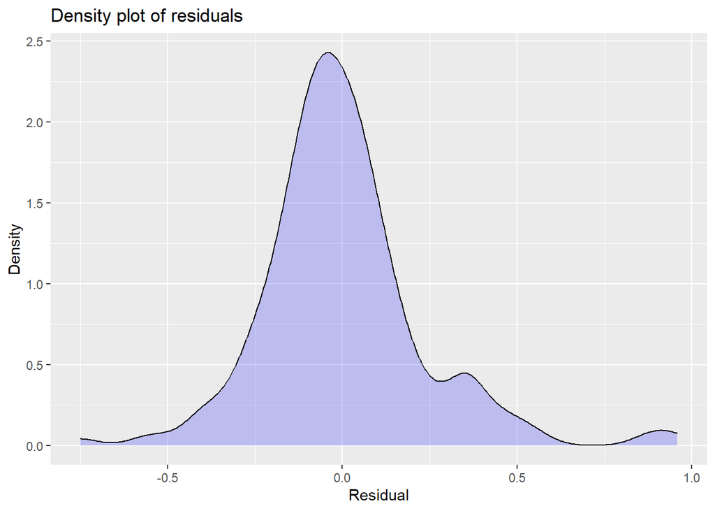

Per osservare la validità della trasformazione, si considerano i grafici del modello lineare e non, rispettivamente in blu ed in rosso:

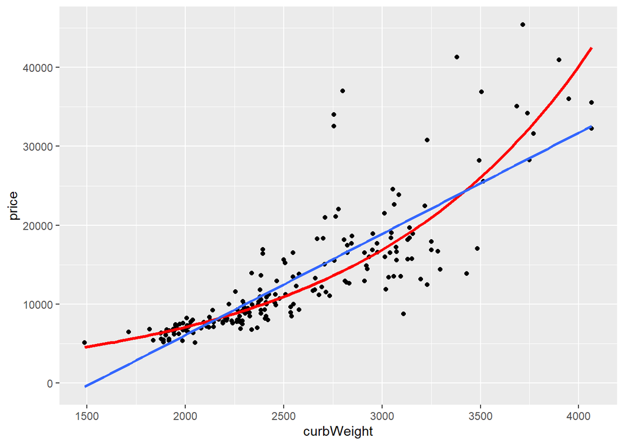

#### *log(price)* *~ horsepower*

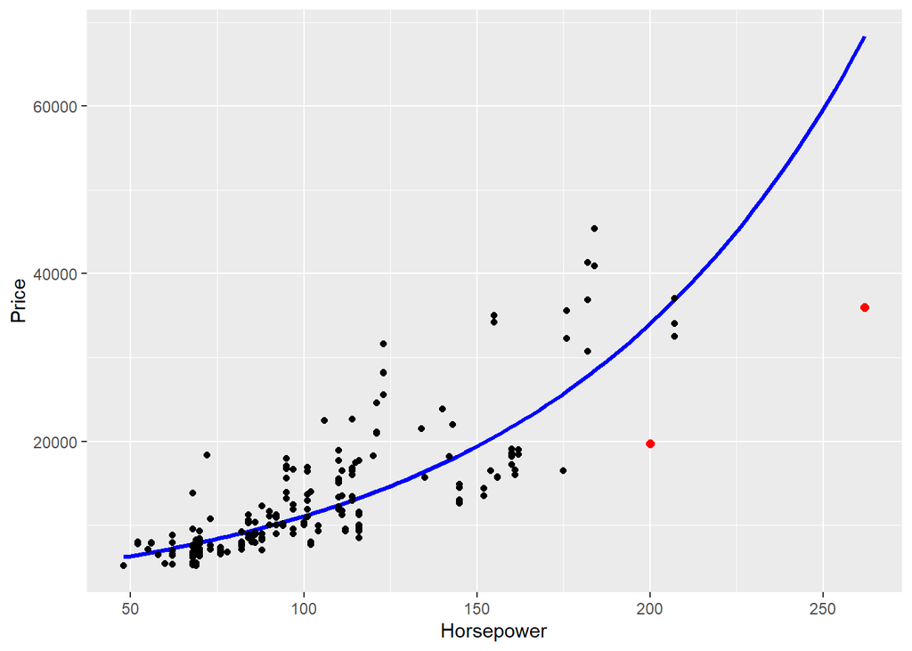

```
##     symboling   make fuelType aspiration numOfDoors bodyStyle driveWheels
## 50          0 jaguar      gas        std        two     sedan         rwd
## 106         3 nissan      gas      turbo        two hatchback         rwd
##     height curbWeight engineType engineSize fuelSystem horsepower peakRpm
## 50    47.8       3950       ohcv        326       mpfi        262    5000
## 106   49.7       3139       ohcv        181       mpfi        200    5200
##     highwayMpg price  logPrice
## 50          17 36000 10.491274
## 106         23 19699  9.888323
```

```
##
## Call:
## lm(formula = logPrice ~ horsepower, data = data)
##
## Residuals:
##      Min       1Q   Median       3Q      Max
## -0.64120 -0.18508 -0.06052  0.19604  0.82050
##
## Coefficients:
##              Estimate Std. Error t value Pr(>|t|)
## (Intercept) 8.1871630  0.0581875  140.70   <2e-16 ***
## horsepower  0.0112417  0.0005283   21.28   <2e-16 ***
## ---
## Signif. codes:  0 '***' 0.001 '**' 0.01 '*' 0.05 '.' 0.1 ' ' 1
##
## Residual standard error: 0.2784 on 197 degrees of freedom
## Multiple R-squared:  0.6968, Adjusted R-squared:  0.6953
## F-statistic: 452.8 on 1 and 197 DF,  p-value: < 2.2e-16
```

Il modello lineare stimato utilizzando come variabile indipendente *horsepower* mostra un $R^2$ pari a $0.6953$. I parametri stimati per l’intecetta e la pendenza della retta di regressione risultano entrambi significativi con p-value minore di $10^{-16}$.

- **Intercetta** = 8.1871630
- **Pendenza** = 0.0112417

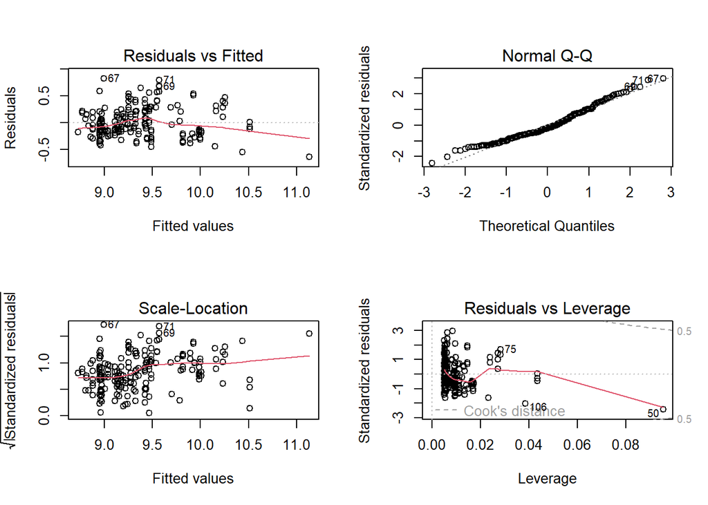

- **residual vs fitted**: i residui mostrano una leggera curvatura ma in generale la linearità del modello pare rispettata. La varianza sembra avere un aumento all’aumentare dei cavalli della macchina
- **QQ-residual**: si osserva un eccellente normalità dei residui con violazioni per i valori di horsepower più bassi
- **scale-location**: si osserva un leggero aumento della varianza all’aumentare dei valori di horsepower
- **residual Vs leverage**: non si osservano dati outlyer, ma si osservano valori che si discostano leggermente dagli altri

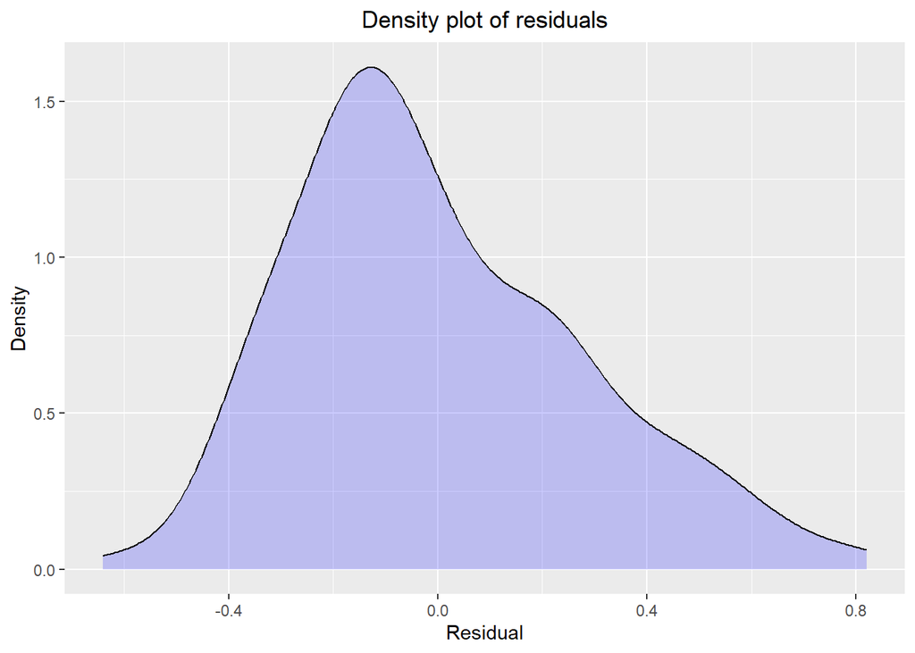

#### *log(price)* *~ engineSize*

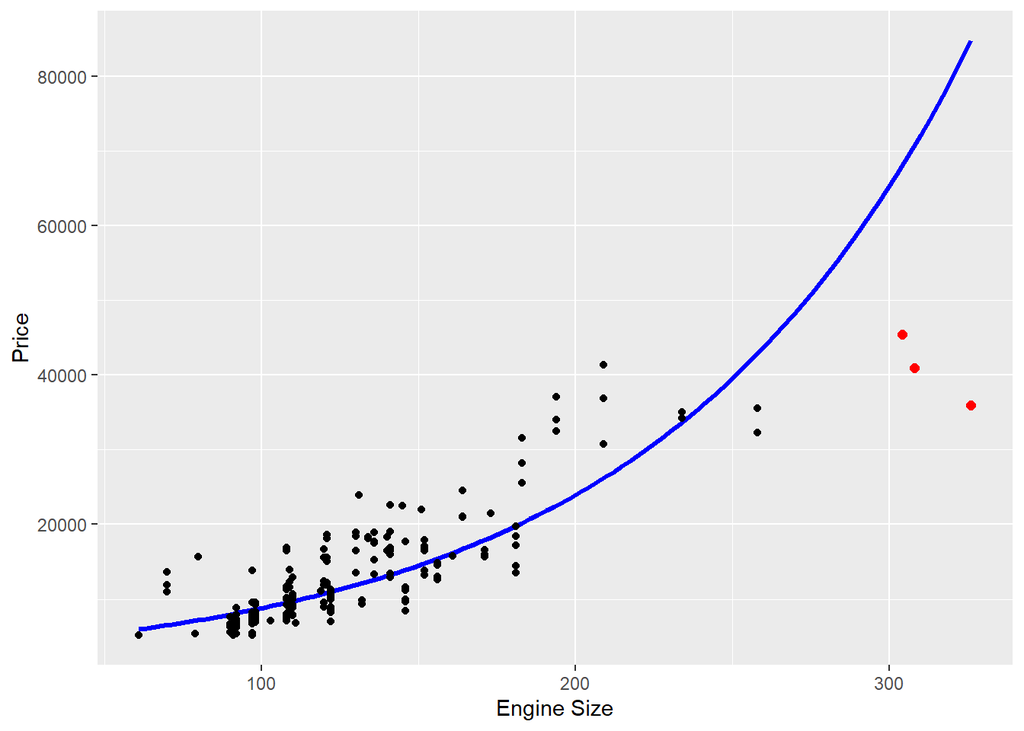

```
##    symboling          make fuelType aspiration numOfDoors bodyStyle driveWheels
## 50         0        jaguar      gas        std        two     sedan         rwd
## 74         0 mercedes-benz      gas        std       four     sedan         rwd
## 75         1 mercedes-benz      gas        std        two   hardtop         rwd
##    height curbWeight engineType engineSize fuelSystem horsepower peakRpm
## 50   47.8       3950       ohcv        326       mpfi        262    5000
## 74   56.7       3900       ohcv        308       mpfi        184    4500
## 75   55.4       3715       ohcv        304       mpfi        184    4500
##    highwayMpg price logPrice
## 50         17 36000 10.49127
## 74         16 40960 10.62035
## 75         16 45400 10.72327
```

```
##
## Call:
## lm(formula = logPrice ~ engineSize, data = data)
##
## Residuals:
##      Min       1Q   Median       3Q      Max
## -0.85668 -0.20215 -0.06391  0.18903  0.77798
##
## Coefficients:
##             Estimate Std. Error t value Pr(>|t|)
## (Intercept) 8.077322   0.064306  125.61   <2e-16 ***
## engineSize  0.010033   0.000481   20.86   <2e-16 ***
## ---
## Signif. codes:  0 '***' 0.001 '**' 0.01 '*' 0.05 '.' 0.1 ' ' 1
##
## Residual standard error: 0.2823 on 197 degrees of freedom
## Multiple R-squared:  0.6883, Adjusted R-squared:  0.6867
## F-statistic:   435 on 1 and 197 DF,  p-value: < 2.2e-16
```

Il modello lineare stimato utilizzando come variabile indipendente *engineSize* mostra un $R^2$ pari a $0.6867$. I parametri stimati per l’intecetta e la pendenza della retta di regressione risultano entrambi significativi con p-value minore di $10^{-16}$.

- **Intercetta** = 8.077322
- **Pendenza** = 0.010033

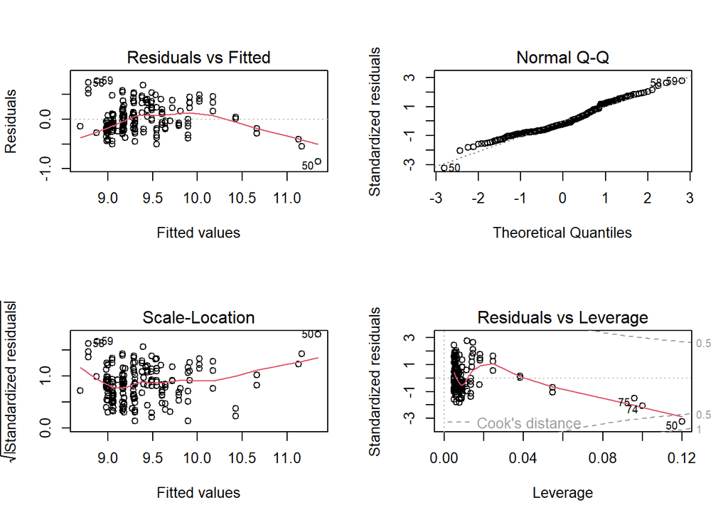

- **residual vs fitted**: si osserva una curvatura dei residui suggerendo una possibile dipendenza quadratica, la scelta del modello lineare potrebbe non essere ottimale
- **QQ-residual**: si osserva una generale distribuzione normale dei residui con una violazione in prossimità della coda sinistra
- **scale-location**: si osserva un leggero aumento della varianza all’aumentare del variabile engineSize
- **residual Vs leverage**: si osserva la presenza di un outlier e altri valori anomali

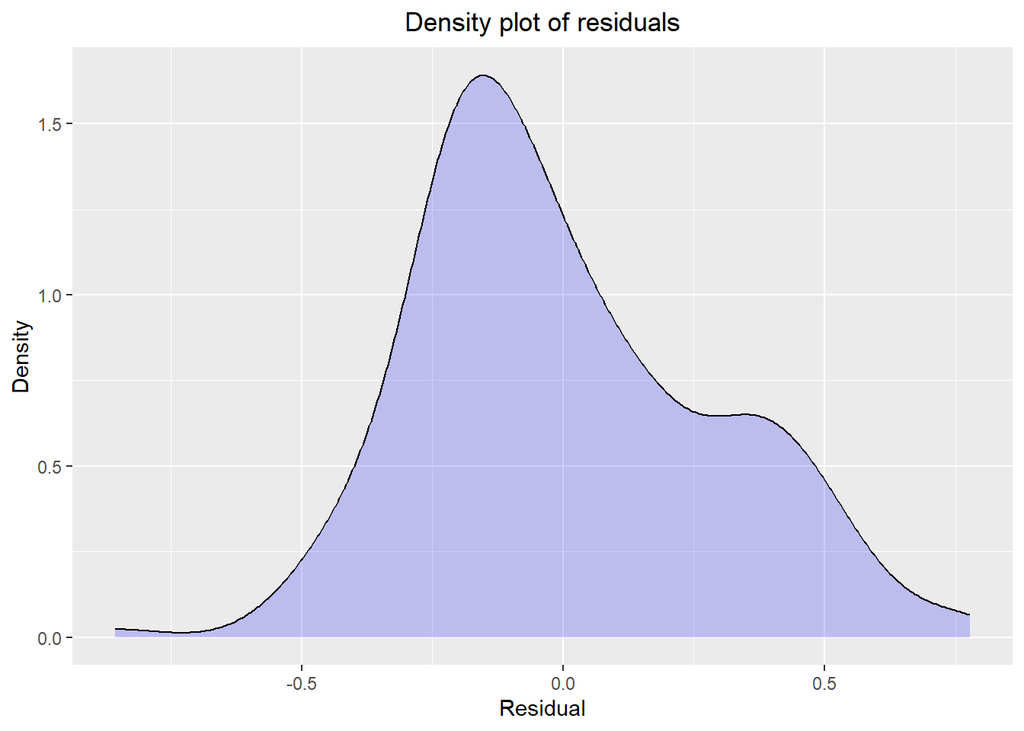

#### *log(price)* *~ highwayMpg*

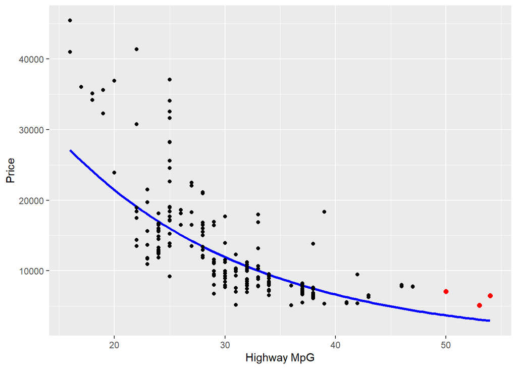

```
##    symboling      make fuelType aspiration numOfDoors bodyStyle driveWheels
## 19         2 chevrolet      gas        std        two hatchback         fwd
## 31         2     honda      gas        std        two hatchback         fwd
## 91         1    nissan   diesel        std        two     sedan         fwd
##    height curbWeight engineType engineSize fuelSystem horsepower peakRpm
## 19   53.2       1488          l         61       2bbl         48    5100
## 31   50.8       1713        ohc         92       1bbl         58    4800
## 91   54.5       2017        ohc        103        idi         55    4800
##    highwayMpg price logPrice
## 19         53  5151 8.546946
## 31         54  6479 8.776321
## 91         50  7099 8.867709
```

```
##
## Call:
## lm(formula = logPrice ~ highwayMpg, data = data)
##
## Residuals:
##      Min       1Q   Median       3Q      Max
## -0.77503 -0.18447 -0.07493  0.15061  0.95405
##
## Coefficients:
##              Estimate Std. Error t value Pr(>|t|)
## (Intercept) 11.141956   0.102024  109.21   <2e-16 ***
## highwayMpg  -0.058435   0.003252  -17.97   <2e-16 ***
## ---
## Signif. codes:  0 '***' 0.001 '**' 0.01 '*' 0.05 '.' 0.1 ' ' 1
##
## Residual standard error: 0.3112 on 197 degrees of freedom
## Multiple R-squared:  0.6211, Adjusted R-squared:  0.6192
## F-statistic: 322.9 on 1 and 197 DF,  p-value: < 2.2e-16
```

Il modello lineare stimato utilizzando come variabile indipendente *highwayMpg* mostra un $R^2$ pari a $0.6192$. I parametri stimati per l’intercetta e la pendenza della retta di regressione risultano entrambi significativi con p-value minore di $10^{-16}$.

- **Intercetta** = 11.14
- **Pendenza** = -0.0584

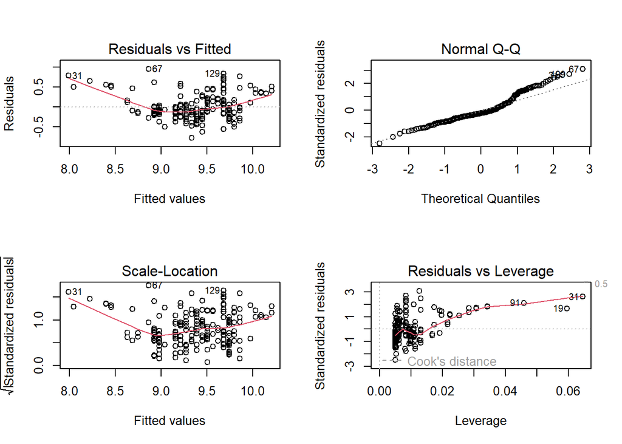

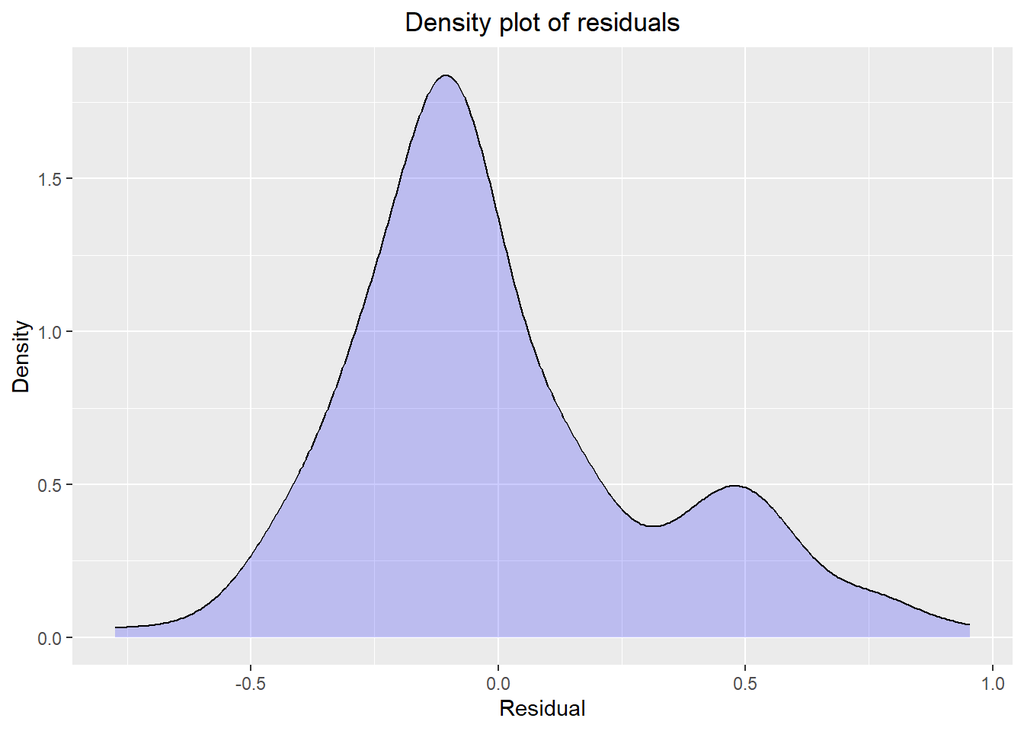

### Conclusioni

La comparazione tra i vari modelli di regressione lineare stimati porta alla conclusione che il modello che utilizza come predittore la variabile *curbWeight* e la variabile *price* in seguito ad una trasformazione logaritmica è il migliore; sia in termini di varianza spiegata, sia in termini di bontà del modello lineare nello studio dei residui.

## 5. Modelli di regressione - multivariata

Dopo aver cercato modelli bivariati che riuscissero a spiegare dei legami tra le variabili, ora ci prefiggiamo di cercare il miglior modello (senza cadere nel rischio di overfitting) che riesca a spiegare la variabile *price*.

Come prima cosa si è notato che prendere in considerazione la trasformazione della variabile *price* migliora significativamente il risultato che possiamo ottenere.

Si è deciso di dividere il dataset in due:

- il dataset per il **training**;
- il dataset per il **testing**.

Questo ci da la possibilità di testare la solidità delle nostre previsioni e cercare quello migliore.

Il dataset viene diviso in due con una funzione pseudocasuale che divide il dataset in 70% training set e 30% testing set.

Successivamente viene utilizzata la funzione `stepAIC()` che tenta automaticamente un gran numero di combinazioni di variabili per trovare il modello migliore.

```
## Start:  AIC=-585.23
## logPrice ~ symboling + make + fuelType + aspiration + numOfDoors +
##     bodyStyle + driveWheels + height + curbWeight + engineType +
##     engineSize + fuelSystem + horsepower + peakRpm + highwayMpg
##
##
## Step:  AIC=-585.23
## logPrice ~ symboling + make + aspiration + numOfDoors + bodyStyle +
##     driveWheels + height + curbWeight + engineType + engineSize +
##     fuelSystem + horsepower + peakRpm + highwayMpg
##
##               Df Sum of Sq     RSS     AIC
## - numOfDoors   1   0.00088 0.96340 -587.11
## - horsepower   1   0.01027 0.97280 -585.77
## - highwayMpg   1   0.01339 0.97591 -585.33
## <none>                     0.96252 -585.23
## - height       1   0.02167 0.98419 -584.16
## - fuelSystem   6   0.10514 1.06766 -582.93
## - peakRpm      1   0.03647 0.99899 -582.10
## - engineSize   1   0.04935 1.01187 -580.33
## - engineType   3   0.07925 1.04177 -580.31
## - symboling    5   0.11263 1.07515 -579.96
## - driveWheels  2   0.06876 1.03128 -579.71
## - bodyStyle    4   0.11633 1.07885 -577.49
## - aspiration   1   0.11067 1.07319 -572.21
## - curbWeight   1   0.25443 1.21696 -554.86
## - make        19   1.41164 2.37416 -498.64
##
## Step:  AIC=-587.11
## logPrice ~ symboling + make + aspiration + bodyStyle + driveWheels +
##     height + curbWeight + engineType + engineSize + fuelSystem +
##     horsepower + peakRpm + highwayMpg
##
##               Df Sum of Sq     RSS     AIC
## - horsepower   1   0.01100 0.97440 -587.54
## - highwayMpg   1   0.01370 0.97711 -587.16
## <none>                     0.96340 -587.11
## - height       1   0.02430 0.98770 -585.67
## - fuelSystem   6   0.10824 1.07164 -584.41
## - peakRpm      1   0.03563 0.99903 -584.09
```

[output cut: 49 more lines]

```
## logPrice ~ symboling + make + aspiration + bodyStyle + driveWheels +
##     height + curbWeight + engineType + engineSize + peakRpm
##
##               Df Sum of Sq    RSS     AIC
## <none>                     1.0732 -588.21
## - height       1   0.02465 1.0979 -587.08
## - engineType   3   0.06143 1.1346 -586.53
## - engineSize   1   0.03449 1.1077 -585.84
## - driveWheels  2   0.05069 1.1239 -585.84
## - symboling    5   0.11157 1.1848 -584.56
## - peakRpm      1   0.05476 1.1280 -583.34
## - bodyStyle    4   0.17357 1.2468 -575.52
## - aspiration   1   0.12630 1.1995 -574.86
## - curbWeight   1   0.39288 1.4661 -547.16
## - make        19   2.01593 3.0892 -480.31
```

Vengono creati altri modelli, a due e tre variabili e poi valutati con il test dell’$R^2$ aggiustato.

```r
# Migliori modelli con due var indipendenti

ml1<-lm(logPrice~curbWeight+make,data = train_data)
ml2<-lm(logPrice~horsepower+make,data = train_data)
ml3<-lm(logPrice~curbWeight+horsepower,data = train_data)


# Migliori modelli con tre variabili indipendenti

ml4<-lm(logPrice~curbWeight+make+height,data = train_data)
ml5<-lm(logPrice~curbWeight+make+bodyStyle,data = train_data)
ml6<-lm(logPrice~curbWeight+make+horsepower,data = train_data)


# Modelli senza make

ml7<-lm(logPrice~curbWeight+horsepower+bodyStyle,data = train_data)
ml8<-lm(logPrice~curbWeight+horsepower+engineSize,data = train_data)
ml9<-lm(logPrice~curbWeight+horsepower+engineType,data = train_data)
ml10<-lm(logPrice~curbWeight+engineType+bodyStyle,data = train_data)

mlt <- lm(logPrice~curbWeight+I(log(horsepower))+make, data = train_data)
```

```r
#R-squared adj

mlRsq.adj<-summary(ml)$adj.r.squared
ml1Rsq.adj<-summary(ml1)$adj.r.squared
ml2Rsq.adj<-summary(ml2)$adj.r.squared
ml3Rsq.adj<-summary(ml3)$adj.r.squared
ml4Rsq.adj<-summary(ml4)$adj.r.squared
ml5Rsq.adj<-summary(ml5)$adj.r.squared
ml6Rsq.adj<-summary(ml6)$adj.r.squared
ml7Rsq.adj<-summary(ml7)$adj.r.squared
ml8Rsq.adj<-summary(ml8)$adj.r.squared
ml9Rsq.adj<-summary(ml9)$adj.r.squared
ml10Rsq.adj<-summary(ml10)$adj.r.squared

mltRsq.adj <- summary(mlt)$adj.r.squared
```

Per valutare la qualità dei modelli è stato usato anche il test AIC.

```r
mlAIC<-AIC(ml)
ml1AIC<-AIC(ml1)
ml2AIC<-AIC(ml2)
ml3AIC<-AIC(ml3)
ml4AIC<-AIC(ml4)
ml5AIC<-AIC(ml5)
ml6AIC<-AIC(ml6)
ml7AIC<-AIC(ml7)
ml8AIC<-AIC(ml8)
ml9AIC<-AIC(ml9)
ml10AIC<-AIC(ml10)

mltAIC <- AIC(mlt)
```

Con i modelli costruiti si è tentato di prevedere dei dati che poi verranno comparati con il dataset di test attraverso il valore dello scarto quadratico medio:

```r
# Utilizzo i modelli per prevedere i valori del test data
pred <-predict(ml,newdata=test_data)
pred1<-predict(ml1,newdata=test_data)
pred2<-predict(ml2,newdata=test_data)
pred3<-predict(ml3,newdata=test_data)
pred4<-predict(ml4,newdata=test_data)
pred5<-predict(ml5,newdata=test_data)
pred6<-predict(ml6,newdata=test_data)
pred7<-predict(ml7,newdata=test_data)
pred8<-predict(ml8,newdata=test_data)
pred9<-predict(ml9,newdata=test_data)
pred10<-predict(ml10,newdata=test_data)

predt <- predict(mlt, newdata=test_data)

# Calcolo scarto quadratico medio rispetto al test data
RMSD <- sqrt(sum((pred - test_data$logPrice)^2)/length(test_data$logPrice))
RMSD1 <- sqrt(sum((pred1 - test_data$logPrice)^2)/length(test_data$logPrice))
RMSD2 <- sqrt(sum((pred2 - test_data$logPrice)^2)/length(test_data$logPrice))
RMSD3 <- sqrt(sum((pred3 - test_data$logPrice)^2)/length(test_data$logPrice))
RMSD4 <- sqrt(sum((pred4 - test_data$logPrice)^2)/length(test_data$logPrice))
RMSD5 <- sqrt(sum((pred5 - test_data$logPrice)^2)/length(test_data$logPrice))
RMSD6 <- sqrt(sum((pred6 - test_data$logPrice)^2)/length(test_data$logPrice))
RMSD7 <- sqrt(sum((pred7 - test_data$logPrice)^2)/length(test_data$logPrice))
RMSD8 <- sqrt(sum((pred8 - test_data$logPrice)^2)/length(test_data$logPrice))
RMSD9 <- sqrt(sum((pred9 - test_data$logPrice)^2)/length(test_data$logPrice))
RMSD10 <- sqrt(sum((pred10 - test_data$logPrice)^2)/length(test_data$logPrice))

RMSDt <- sqrt(sum((predt - test_data$logPrice)^2)/length(test_data$logPrice))
```

I valori infine vengono graficati in tre grafici:

- $R^2$ aggiustato
- AIC
- scarto quadratico medio con il dataset di testing

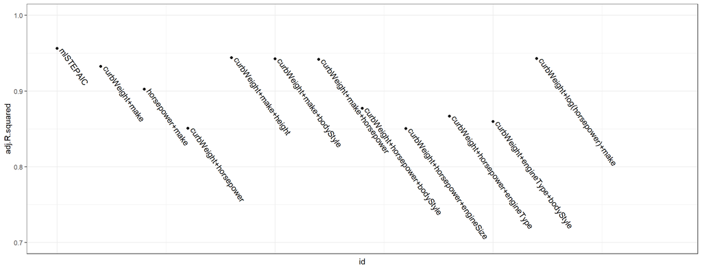

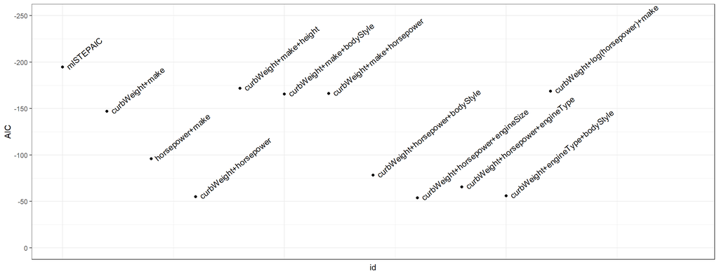

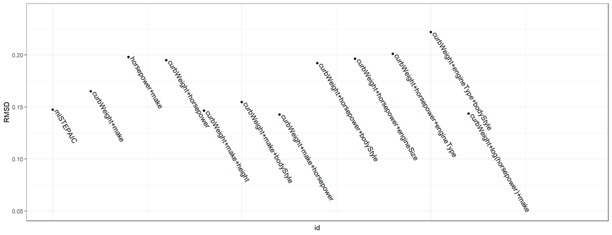

## Conclusioni

Sembra quindi emergere che *curbWeight* sia una variabile molto significativa, leggermente di più di *make, horsepower, bodyStyle* e *engineType*.